# AssetAllocation

일반적인 개인 투자자가 구현하기에 조금 더 쉬운 방식인 자산군 수익률의 n배수를 하겠습니다. 레버리지 ETF를 쓰는 것과 비슷한 방식입니다. (레버리지 ETF는 일간 수익률 기준으로 만들기 때문에 현재 구현하는 것과 같을 수 없습니다) 레버리지 ETF 비용은 무시하고 진행합니다. 1.6배 정도의 레버리지를 하겠습니다. 현금(단기국채)에 대한 레버리지는 보통 하지 않으므로 그것은 제외합니다.

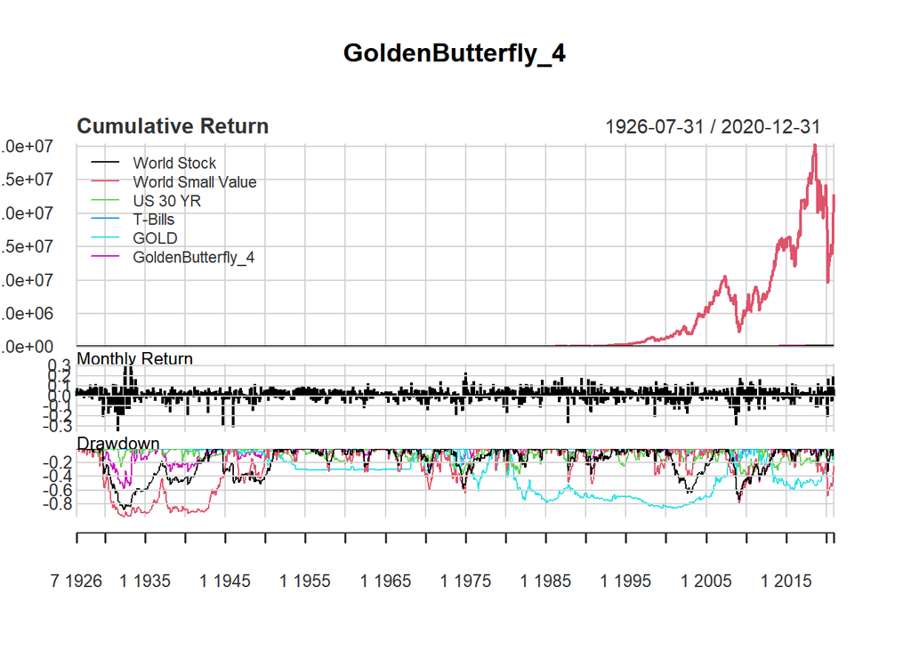

```r
# 황금나비 4 : 전세계주식 : 소형가치 : 장기국채 : 단기국채 : 금  = 1 : 1 : 1 : 1 : 1
port_GoldenButterfly_4 = Return.portfolio(R = rets_GoldenButterfly_4, weights = c(1/5, 1/5, 1/5, 1/5, 1/5),
                                          rebalance_on = 'years')

GoldenButterfly_4 = cbind(rets_GoldenButterfly_4, port_GoldenButterfly_4) %>%
  setNames(c('World Stock', 'World Small Value', 'US 30 YR', 'T-Bills', 'GOLD', 'GoldenButterfly_4'))

charts.PerformanceSummary(GoldenButterfly_4, main = 'GoldenButterfly_4')
```

```
##         From     Trough         To   Depth Length To Trough Recovery
## 1 1929-09-30 1932-05-31 1933-06-30 -0.5741     46        33       13
## 2 1937-03-31 1938-03-31 1943-02-28 -0.3287     72        13       59
## 3 1969-06-30 1970-06-30 1971-02-28 -0.2599     21        13        8
## 4 2008-03-31 2009-02-28 2009-09-30 -0.2297     19        12        7
## 5 1974-04-30 1974-09-30 1975-01-31 -0.2293     10         6        4
```

표 16: Golden Butterfly_4 (1.6x monthly return) 성과: 1926.07 ~ 2020.12

| 전략 | 누적 수익 | 연복리 수익률 | 표준편차 | 샤프 비율 | 최대 하락폭 |
| --- | --- | --- | --- | --- | --- |
| Golden Butterfly_4 | 156033배 | 13.49% | 14.89% | 0.657 | 57.41% |
| World Stock | 150034배 | 13.44% | 23.20% | 0.420 | 87.96% |
| World Small Value | 22822191배 | 19.64% | 45.16% | 0.348 | 98.03% |
| US 30 YR | 2451배 | 8.61% | 16.33% | 0.309 | 39.38% |
| GOLD | 524배 | 6.85% | 24.15% | 0.138 | 85.89% |
| 현금(T-Bill) | 23배 | 3.39% | 0.88% | 0 | 0 |

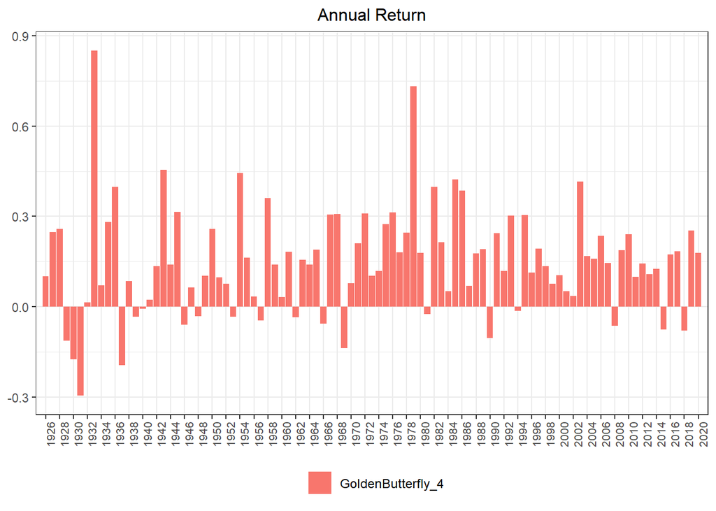

```r
Return.cumulative(port_GoldenButterfly_4)
Return.annualized(port_GoldenButterfly_4)
Return.cumulative(rets_GoldenButterfly_4)
Return.annualized(rets_GoldenButterfly_4)

StdDev.annualized(port_GoldenButterfly_4)
StdDev.annualized(rets_GoldenButterfly_4)

SharpeRatio.annualized(port_GoldenButterfly_4, Rf = rets_GoldenButterfly_4$T.Bills, geometric = TRUE)
SharpeRatio.annualized(rets_GoldenButterfly_4, Rf = rets_GoldenButterfly_4$T.Bills, geometric = TRUE)

maxDrawdown(port_GoldenButterfly_4)
maxDrawdown(rets_GoldenButterfly_4)
```

월간 수익률에 1.6배 레버리지를 한 결과입니다. 전략은 누적 수익률 156033배, 연복리 13.49%, 연 변동성 14.89%의 결과를 냅니다. 같은 기간 전세계 주식시장은 누적 150034배, 연복리 13.44%, 연 변동성 23.20%입니다. 주식시장보다 수익률이 높고 변동성은 낮은 전략이 나왔습니다. 샤프 비율은 0.657으로 레버리지 없는 전략보다 높습니다. 그러나, 하락폭은 확실히 큽니다. 차입으로 구현한 것과 마찬가지로 20% 이상의 하락이 5회 이상 발생합니다. 월간 수익률에 직접 레버리지 비율을 곱하기 때문에 전체적인 자산군의 성과가 좋을 때 효과가 극대화될 것입니다. 반대로 추세가 모호하다면 레버리지 배수보다 못한 수익이 나올 것입니다.

## 3.7. 전략 개선 - All Seasons

먼저 Ray Dalio와 Bridgewater Associates가 그들의 베타 전략인 all weather 전략에 대하여 설명한 내용을 보겠습니다. Ray Dailo와 Bridgewater Associates는 그들의 문서에서 울웨더 포트폴리오에 관하여 더 자세히 설명하고 있습니다. Bridgewater Associates는 어떤 경제 상황에 있더라도 꾸준한 수익을 내는 것을 원했습니다. 그들은 경제 상황을 인플레이션과 경제 성장을 가지고 4가지 경우로 정의했습니다. 각각은 (인플레이션율 기대 이상, 경제성장률 기대 이상), (인플레이션율 기대 이상, 경제성장률 기대 이하), (인플레이션율 기대 이하, 경제성장률 기대 이상), (인플레이션율 기대 이하, 경제성장률 기대 이하) 입니다. 그림으로 나타내면 다음과 같습니다.

#

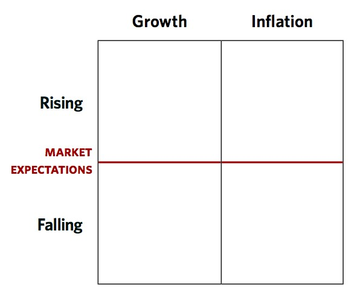

경제 상황별 다양한 시나리오가 있을 것이나, 경제 성장률은 경제 활동의 양을, 인플레이션율은 가격 상승률을 의미한다고 생각하면 수량과 가격을 모두 고려한 것이므로, 두 가지 요인으로 만든 4가지 경우로 경제 상황을 설명할 수 있을 것입니다. 일반적으로 인플레이션이 높을 때 주식과 채권의 성과가 부진합니다. 대부분의 투자자는 인플레이션 방어를 위해 원자재만을 대안으로 생각합니다. Bridgewater Associates는 더 높은 수준의 다각화를 위하여 원금과 이자 지급액을 물가에 연동시키는 물가연동채권을 고안했습니다. 물가연동채권은 원자재처럼 인플레이션이 기대 이상일 때 방어 능력이 있는데, 경제 성장률에 관해서는 반대 성향을 가지고 있습니다. 그들의 연구에 따르면 각각의 경우에서 성과가 좋은 자산은 다음과 같습니다.

#

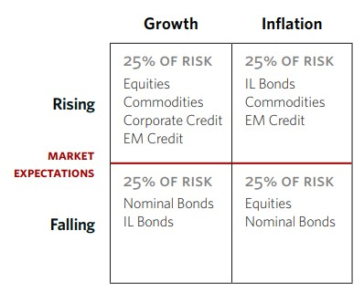

경제 성장률이 기대보다 높으면 기업들이 기대보다 돈을 잘 벌었다는 것이 되므로 주식의 성과는 좋을 것입니다. 회사채도 돈을 잘 갚을 것으로 기대되니 좋을 것입니다. 원자재도 수요가 증가하여 가격이 오를 것이고 성과가 좋을 것입니다. 신흥국 국채 또한 신흥국이 원자재 수출을 하는 경우가 많고, 공급 체인 끝에 위치하여 전세계가 호황이라면 신흥국이 더 호황일 가능성이 높아 성과가 좋을 것입니다. 경제 성장률이 기대보다 낮으면 안전 자산을 선호하게 되므로 명목 국채의 성과가 좋을 것입니다. 물가연동채권 역시 명목 국채에 인플레이션을 보정해주는 것이므로 성과가 좋을 것입니다. 인플레이션이 기대 이상이라면 인플레이션을 보정하는 물가연동채권이 좋을 것이고, 물건 값이 오르는 시기이므로 원자재의 성과도 좋을 것입니다. 금은 먼 옛날부터 화폐의 역할을 가졌고, 인플레이션이 올 때마다(화폐 가치가 하락할 때마다) 주목받았으므로 인플레이션이 기대 이상일 때 좋을 것입니다. 신흥국 국채는 FED의 금리 인상 등 긴축 정책으로 신흥국의 부채 부담이 늘어나는 피해를 입지 않는다는 전제 하에 신흥국이 원자재를 파는 경우가 많아 수출 실적이 좋아져 신흥국 국채 성과도 좋을 수 있습니다.

인플레이션이 기대 이하라면 대공황과 같은 상황이 아니라면 일반적으로 중앙 은행이 인플레이션을 목표치로 올리기 위해 화폐 공급을 늘릴 것이고, 그러면 할인율이 내려간 것으로 인식할 수 있어 자산 가격이 비싸지므로 국채와 주식이 괜찮습니다. 미래에 어떤 상황이 펼쳐질지 모른다는 가정 하에서 4가지 경우에 위험을 25%씩 분산하여 모든 상황에 대응할 수 있도록 하는 것이 목표입니다. 과거의 변동성과 성과를 가지고 미래의 리스크 비중을 예측하는 것이라 완벽하게 정확할 수는 없겠지만, 기존의 6:4나 4:6 전략보다 위험 대비 수익이 높을 것이고, Tony Robbins의 책에 나오는 올시즌스 포트폴리오보다 다각화 수준이 높아 장기적으로 우위를 가질 것입니다. Bridgewater Associates는 4가지 상황에 포트폴리오의 위험을 균등 배분한다는(Risk Parity) 점에서 이 전략을 All Weather 전략이라고도 부릅니다. 이런 전략이 언제 돈을 잃을지도 생각해보아야 합니다. 전략의 수익률이 현금보다 못하면 돈을 잃을 것입니다. 중앙은행이 긴축 정책을 하여 금리를 올리면 자산에 대한 할인율이 올라 자산이 만들어 줄 미래 현금흐름이 줄어들고, 자산들의 현재 가치가 떨어질 것입니다. 또한, 금리가 오르면 현금으로도 이자를 잘 받을 수 있어서 자산을 현금화하려는 움직임이 일어납니다. 이 경우 매우 드물게 전략 내 모든 자산군이 하락할 수 있으나, 투자와 소비 감소에 따른 경제 수축을 동반하므로 중앙은행이 개입하여 경제 수축을 막으려 할 것입니다. 그러므로, 이런 전략들이 약세인 구간이 있더라도 기존의 6:4, 주식 100% 같은 전략들보다는 회복도 빠르고 경험하는 하락폭도 작을 것입니다.

앞에서 본 All Seasons 전략의 문제점은 주식에서의 문제점, 국채에서의 문제점으로 나눌 수 있습니다. 주식은 GoldenButterfly 전략의 문제처럼 국가 분산이 필요합니다. 그러므로, 전세계 주식을 사용하는 것으로 하겠습니다. 국채의 문제점은 장기 국채와 중기 국채 두 가지 모두 사용해야 할 이유가 없습니다. 어차피 자산배분을 하여 변동성은 제한적이므로, 수익률을 높이기 위해 장기 국채만 사용하는 것으로 하겠습니다. 그리고, 장기 국채는 금리 하락 시에는 매우 좋지만 금리 상승 시에는 매우 취약합니다. 따라서, 금과 원자재를 포함하지만, 장기 국채의 손실을 더 방어하기 위해 물가연동채권을 사용할 것입니다. 주식은 전세계 주식을 사용하더라도 시가총액 가중 방식의 지수를 사용하기 떄문에 미국 주식을 배제하지 않으므로 괜찮지만, 장기 국채와 물가연동채권의 비중을 어떻게 가져갈 것인지, 물가연동채권의 만기는 어떻게 할 것인지, 장기 국채를 가져가는 것이 맞는지에 대한 문제가 있습니다. 그것은 다른 연구들을 보겠습니다.

코로나19로 인해 달러가 너무 많이 공급되었고 이것이 인플레이션을 부를 것이라는 우려가 있습니다. 그런 관점에서, 현재의 제로 금리는 금리 인하로부터 장기 국채가 얻어낼 수익이 없어진 것 같아 부정적으로 보입니다. 그러나, 금리를 예측하는 것은 아래 그림에서 보이듯이 가장 어려운 문제 중 하나입니다. 검은색의 진한 선이 실제 10년물 금리이고, 연한 선들이 채권 및 거시 경제 전문가들이 예측한 금리 방향입니다. 20년 동안 제대로 맞춘 적이 거의 없습니다.

#

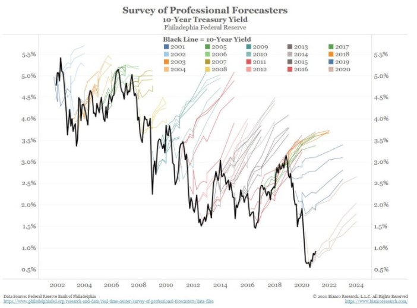

그리고, 장기 국채를 대체하여 주식 시장의 위험을 헤지하고, 장기적으로 우상향하고, 개인 투자자들도 쉽게 접근할 수 있는 자산을 찾는 것은 매우 어렵습니다. 만약 인플레이션 상황으로 간다고 하더라도, 소비자물가지수에 맞게 원금과 이자를 보정하여 국채가 인플레이션에서 입는 피해를 방어하는 목적으로 설계된 물가연동채권도(TIPS) 만기가 긴 것을 사용해야 장기 국채를 대체하면서 수익을 낼 수 있는데, 장기 TIPS는 인플레이션 방어 기능은 그리 크지 않습니다. 그렇다고 만기가 짧은 TIPS를 사용한다면 인플레이션 방어는 될 수 있으나 만기가 짧으므로 수익률을 포기해야 하고, 일반적인 단기 국채와 큰 차이가 없습니다. Vanguard의 연구에 따르면, 단기적인 인플레이션 급등에서 10년 이상의 만기를 가지는 TIPS들은 인플레이션과의 수익 상관관계가 낮아 인플레이션 방어 효과가 떨어집니다. 아래 그림들이 TIPS 만기별 인플레이션과 수익률 사이의 상관관계를 나타낸 그림입니다.

#

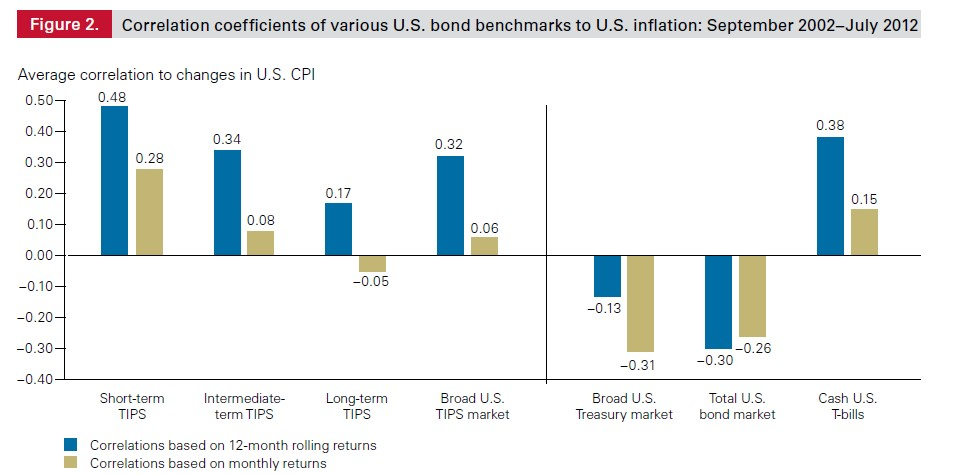

#

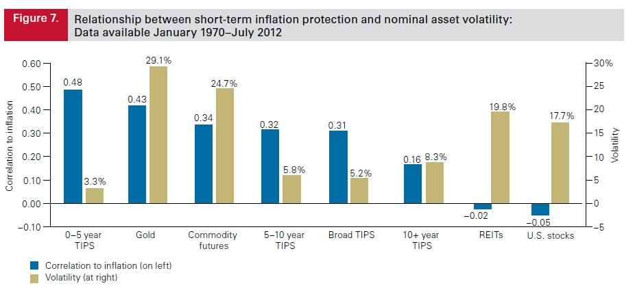

#

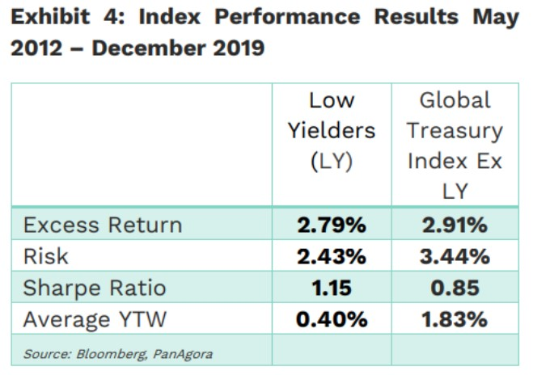

#

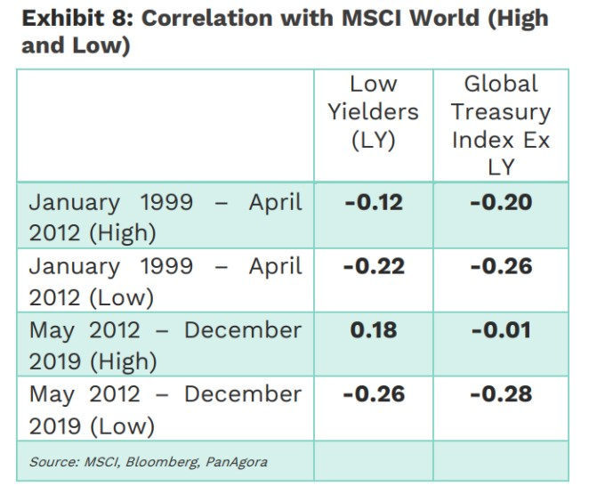

그러므로, 장기 국채는 가져가고, 전세계적인 저금리 추세에 맞도록 비중을 낮추면서 편의상 물가연동국채와 1:1로 가져가는 것으로 해 보겠습니다.

Bridgewater Associates가 제시한 그림에서는 회사채와 신흥국 국채도 가져가는 것으로 되어 있습니다. 회사채는 결국 회사의 미래가 어떻게 되는가에 따라 움직이게 되므로 주식과 같이 움직일 수밖에 없습니다. 그러므로, 회사채는 테스트에서 제외합니다. 신흥국 국채는 지역 화폐로 발행된 것을 기준으로 한다면 인플레이션 시기에 원자재를 팔아 신흥국 경기가 좋을 것이라 신흥국 국채의 가치가 오르고, 인플레이션에 대한 방어가 가능할 것입니다. 그러나, 로컬 화폐로 발행된 국채들로 만들었으며, 만기가 충분히 길어서 수익률에 유의미한 도움을 줄 수 있는 투자 상품이 딱히 없습니다. 일반적인 투자자들이 국채를 직접 운용할 수는 없으므로 신흥국 국채도 제외합니다.

1차로 결정된 자산군은 전세계 주식, 미국 장기 국채, 미국 물가연동국채, 금, 원자재입니다. 최적화하기 전 초기 비중은 All Seasons 전략을 변형하여 주식 30 : 미국 장기 국채 27.5 : 미국 물가연동국채 27.5 : 금 7.5 : 원자재 7.5로 하겠습니다.

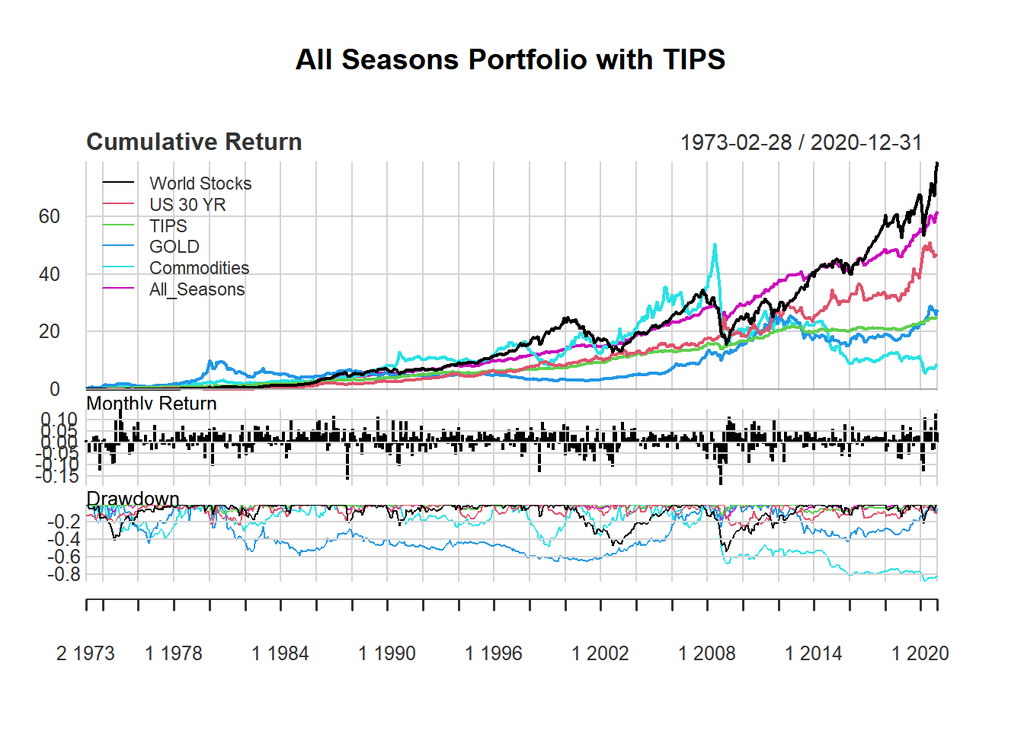

```r
port_All_Seasons_3 = Return.portfolio(R = rets_All_Seasons_3, weights = c(0.3, 0.275, 0.275, 0.075, 0.075),
                                      rebalance_on = 'years')
All_Seasons_3 = cbind(rets_All_Seasons_3, port_All_Seasons_3) %>% setNames(c('World Stocks', 'US 30 YR', 'TIPS', 'GOLD',
                                                                             'Commodities', 'All_Seasons'))

charts.PerformanceSummary(All_Seasons_3, main = 'All Seasons Portfolio with TIPS')
```

```r
Return.cumulative(port_All_Seasons_3)
Return.annualized(port_All_Seasons_3)
Return.cumulative(rets_All_Seasons_3)
Return.annualized(rets_All_Seasons_3)

StdDev.annualized(port_All_Seasons_3)
StdDev.annualized(rets_All_Seasons_3)

SharpeRatio.annualized(port_All_Seasons_3, Rf = ReturnTimeSeries$`T-Bills`[878:1452], geometric = TRUE)
SharpeRatio.annualized(rets_All_Seasons_3, Rf = ReturnTimeSeries$`T-Bills`[878:1452], geometric = TRUE)

maxDrawdown(port_All_Seasons_3)
maxDrawdown(rets_All_Seasons_3)
```

표 17: All Seasons_3 (TIPS) 성과: 1973.02 ~ 2020.12

| 전략 | 누적 수익 | 연복리 수익률 | 표준편차 | 샤프 비율 | 최대 하락폭 |
| --- | --- | --- | --- | --- | --- |
| All Seasons | 62.7배 | 9.02% | 7.47% | 0.563 | 17.16% |
| World Stock | 80.1배 | 9.58% | 15.03% | 0.315 | 53.65% |
| US 30 YR | 46.2배 | 8.38% | 12.90% | 0.278 | 25.84% |
| TIPS | 26.2배 | 7.05% | 6.05% | 0.384 | 11.89% |
| GOLD | 28.6배 | 7.25% | 20.04% | 0.125 | 64.97% |
| Commodities | 9.6배 | 4.84% | 20.89% | 0.010 | 80.90% |

```
##         From     Trough         To   Depth Length To Trough Recovery
## 1 2008-07-31 2008-10-31 2009-11-30 -0.1716     17         4       13
## 2 1980-07-31 1981-09-30 1981-11-30 -0.1057     17        15        2
## 3 1980-02-29 1980-03-31 1980-05-31 -0.0982      4         2        2
## 4 1974-03-31 1974-09-30 1975-01-31 -0.0867     11         7        4
## 5 1990-01-31 1990-04-30 1990-11-30 -0.0808     11         4        7
```

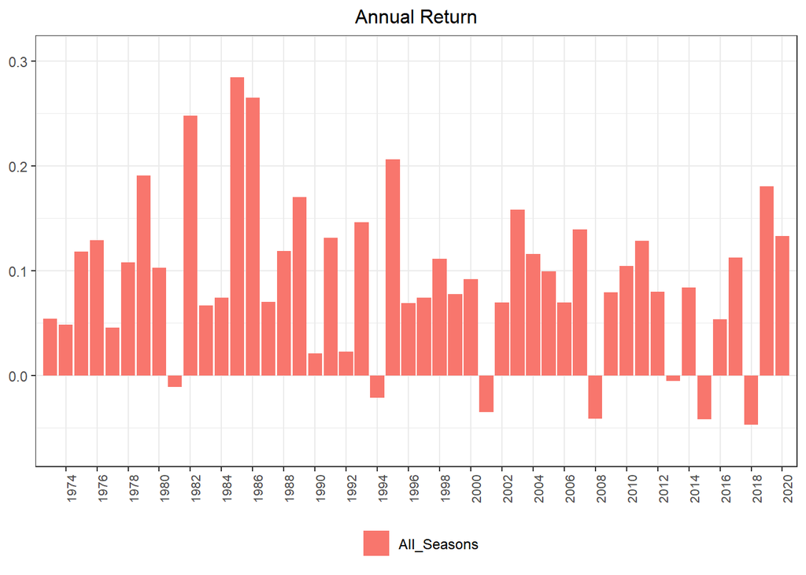

```r
table.Drawdowns(port_All_Seasons_3)
```

1973년 2월부터 누적 수익률 62.7배, 연복리 수익률 9.02%, 연 변동성 7.47%, 샤프 비율 0.563으로 괜찮습니다. 테스트 기간 동안 최대 하락은 17%이며, 10%를 넘는 하락은 단 2회입니다.

이제 TIPS를 사용하는 전략을 최적화합니다. 최적화에는 위험 균형 방식이 많이 쓰이므로, 위험 균형 (Risk Parity) 방식을 테스트할 것입니다. 위험 균형 방식을 구현하기 위해서는 한계 위험기여도와 (Marginal Risk Contribution, MRC) 위험기여도를 (Risk Contribution, RC) 알아야 합니다. 한계 위험기여도는 특정 자산 비중을 1단위 증가시킬 때 전체 포트폴리오 위험의 증가를 나타내는 단위로, 편미분 개념입니다. $i$번째 자산의 한계 위험기여도는 다음과 같습니다.

$$MRC_i = \frac{\partial\sigma_p}{\partial w_i}$$

$\sqrt {f(x)} = \frac{f'(x)}{2\sqrt{f(x)}}$이므로, 한계 위험기여도는 다음과 같이 풀 수 있습니다. 결과적으로 분자는 분산-공분산 행렬과 각 자산의 비중의 곱, 분모는 포트폴리오의 표준편차 형태로 나타납니다.

$$\begin{equation*}
\begin{split}
\frac{\partial\sigma_p}{\partial w} & = \frac{\partial(\sqrt{w'\Omega w})}{\partial w} \\
& =\frac{\partial(w'\Omega w)}{\partial w} \times \frac{1}{2\sqrt{w'\Omega w}} \\
& =\frac{2\Omega w}{2\sqrt{w'\Omega w}} \\
& =\frac{\Omega w}{\sqrt{w'\Omega w}}
\end{split}
\end{equation*}$$

위험기여도는 특정 자산이 포트폴리오에서 차지하는 위험 비중입니다. 한계 위험기여도가 크더라도 포트폴리오 내의 비중이 작으면 포트폴리오 전체에 대한 위험 기여도는 낮을 것이고, 반대로 한계 위험기여도가 작더라도 포트폴리오 내의 비중이 크면 포트폴리오 전체에 대한 위험 기여도는 높을 것입니다. 그러므로, 위험 기여도는 한계 위험기여도와 포트폴리오 내 비중의 곱으로 표현됩니다.

$$RC_i = \frac{\partial\sigma_p}{\partial w_i} \times w_i$$
위험기여도를 코드로 나타내면 다음과 같습니다. 먼저 포트폴리오 비중인 $w$와 분산-공분산 행렬인 covmat을 이용해 한계 위험기여도를 계산합니다. 그 후 비중 $w$를 곱해 위험기여도를 계산해 준 후 합계가 1이 되도록 표준화를 해줍니다.

```r
get_RC = function(w, covmat) {
  port_vol = t(w) %*% covmat %*% w
  port_std = sqrt(port_vol)

  MRC = (covmat %*% w) / as.numeric(port_std)
  RC = MRC * w
  RC = c(RC / sum(RC))

  return(RC)
}
```

저렇게 직접 구할 수도 있지만, 매번 하기 번거로우니 cccp 패키지의 rp 함수를 사용하겠습니다. rp 함수를 사용하여 전체 구간에서의 위험 균형 방식의 최적화를 해 보겠습니다.

```r
covmat1 = cov(rets_All_Seasons_3)

opt_rp1 = rp(x0 = rep(0.2, 5),
             P = covmat1,
             mrc = rep(0.2, 5))
```

x0는 최적화를 위한 초기값이고, 일단 동일 비중인 20%를 넣습니다. P는 variance-covariance matrix가 들어갑니다. mrc는 목표로 하는 자산별 위험 기여도 값이고, 위험 균형을 원하므로 20%씩 할당합니다.

```r
w1 = getx(opt_rp1) %>% drop()
w1 = (w1 / sum(w1)) %>% round(., 4) %>% setNames(colnames(rets_All_Seasons_3))

print(w1)
```

```
## World.Stocks     US.30.YR  TIPS.Series         GOLD         GSCI
##       0.1767       0.2199       0.3382       0.1304       0.1348
```

rp() 함수는 최적해를 찾고, getx() 함수로 해를 뽑아낸 후 drop() 함수로 벡터로 만듭니다. 그리고, 비중의 합이 1이 되도록 가공합니다. 1973년 2월 ~ 2020년 12월의 월간 데이터 기준으로, TIPS를 사용하는 All Seasons 전략을 위험 균형 최적화하면 전세계 주식 17.67%, 미국 장기 국채 21.99%, TIPS 33.82%, 금 13.04%, 원자재 13.48%를 가져가게 됩니다. 성과는 어떤지 테스트합니다.

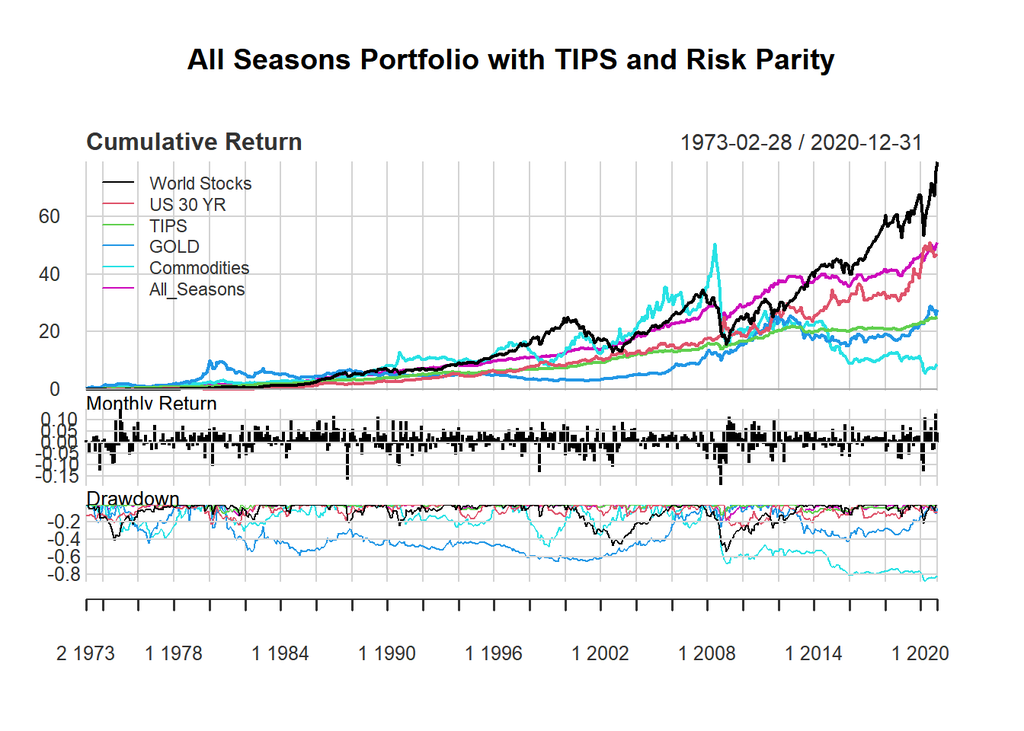

```r
port_All_Seasons_4 = Return.portfolio(R = rets_All_Seasons_4, weights = c(0.1767, 0.2199, 0.3382, 0.1304, 0.1348),
                                      rebalance_on = 'years')
All_Seasons_4 = cbind(rets_All_Seasons_4, port_All_Seasons_4) %>% setNames(c('World Stocks', 'US 30 YR', 'TIPS', 'GOLD',
                                                                             'Commodities', 'All_Seasons'))

charts.PerformanceSummary(All_Seasons_4, main = 'All Seasons Portfolio with TIPS and Risk Parity')
```

```r
Return.cumulative(port_All_Seasons_4)
Return.annualized(port_All_Seasons_4)
Return.cumulative(rets_All_Seasons_4)
Return.annualized(rets_All_Seasons_4)

StdDev.annualized(port_All_Seasons_4)
StdDev.annualized(rets_All_Seasons_4)

SharpeRatio.annualized(port_All_Seasons_4, Rf = ReturnTimeSeries$`T-Bills`[878:1452], geometric = TRUE)
SharpeRatio.annualized(rets_All_Seasons_4, Rf = ReturnTimeSeries$`T-Bills`[878:1452], geometric = TRUE)

maxDrawdown(port_All_Seasons_4)
maxDrawdown(rets_All_Seasons_4)
```

표 18: All Seasons_4 (with TIPS and Risk Parity) 성과: 1973.02 ~ 2020.12

[output not shown]

```
##         From     Trough         To   Depth Length To Trough Recovery
## 1 2008-07-31 2008-10-31 2010-04-30 -0.1921     22         4       18
## 2 1980-07-31 1981-09-30 1982-08-31 -0.1254     26        15       11
## 3 1980-02-29 1980-03-31 1980-05-31 -0.1089      4         2        2
## 4 2014-09-30 2015-12-31 2017-08-31 -0.1063     36        16       20
## 5 2012-10-31 2013-06-30 2014-05-31 -0.0804     20         9       11
```

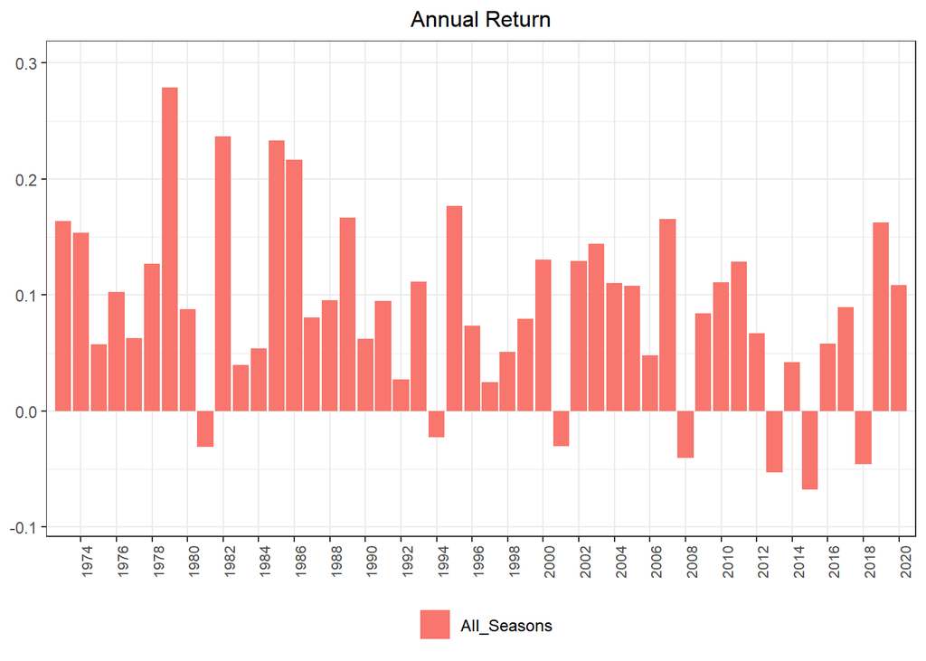

```r
table.Drawdowns(port_All_Seasons_4)
```

먼저 기간별로 risk parity를 맞춘 투자 비중을 계산해야 합니다.

```r
# risk parity: 12m rolling, 3m rebalance
rWindows = fPortfolio::rollingWindows(rets_All_Seasons_3, period = '12m', by = '3m')

# rebalance date은 이럴 것임
print(rWindows$to)

# Apply FUN to time series R in the subset [from, to]
ApplyFilter = function(from, to, R, FUN){
  return(FUN(R[paste0(from, "/", to)]))
}

# For each pair (from, to) ApplyFilter to time-series R using FUN
ApplyRolling = function(from, to, R, FUN){
  # 반복 작업에 사용
  library(purrr)
  return(purrr::map2(from, to, ApplyFilter, R=R, FUN=FUN))
}

# Returns weights of a risk parity portfolio from covariance matrix of return r. Now: for 5 assets
CalculateRiskParity = function(r){
  library(cccp)
  library(magrittr)
  covmat = cov(r)

  opt_rp = rp(x0 = rep(1/5, 5),
              P = covmat,
              mrc = rep(1/5, 5))

  w = getx(opt_rp) %>% drop()
  w = (w / sum(w)) %>% round(., 4) %>% setNames(colnames(r))

  return(w)
}

# Given a matrix return 'r'
# calculates risk parity weights for each date in 'to' considering a time window from 'from' and 'to'
RollingRiskParity = function(from, to, r){
  library(rlist)
  p = ApplyRolling(from, to, r, CalculateRiskParity)
  names(p) = to
  return(list.rbind(p))
}

# rWindows$from@Data: from의 Data만 추출
parity.weights = RollingRiskParity(rWindows$from@Data, rWindows$to@Data, rets_All_Seasons_3)
```

1973년 2월부터의 데이터로 risk parity 계산을 했습니다. 기간별 구성을 그림으로 한 번 보겠습니다.

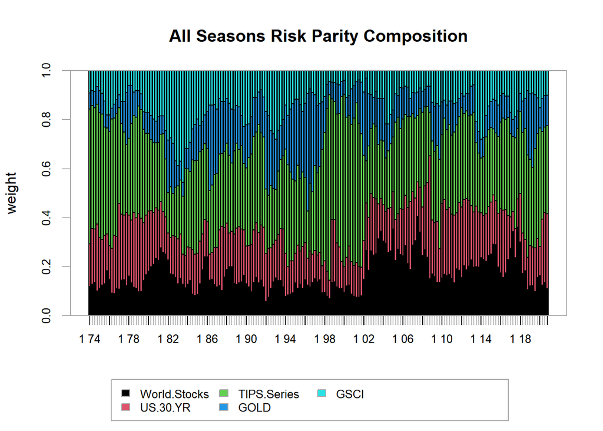

```r
PerformanceAnalytics::chart.StackedBar(parity.weights,
                                       xlab = 'Rebalance Dates',
                                       ylab = 'weight',
                                       main = 'All Seasons Risk Parity Composition')
```

이제 성과 분석을 하겠습니다. 1974년 1월부터 시작하게 됩니다.

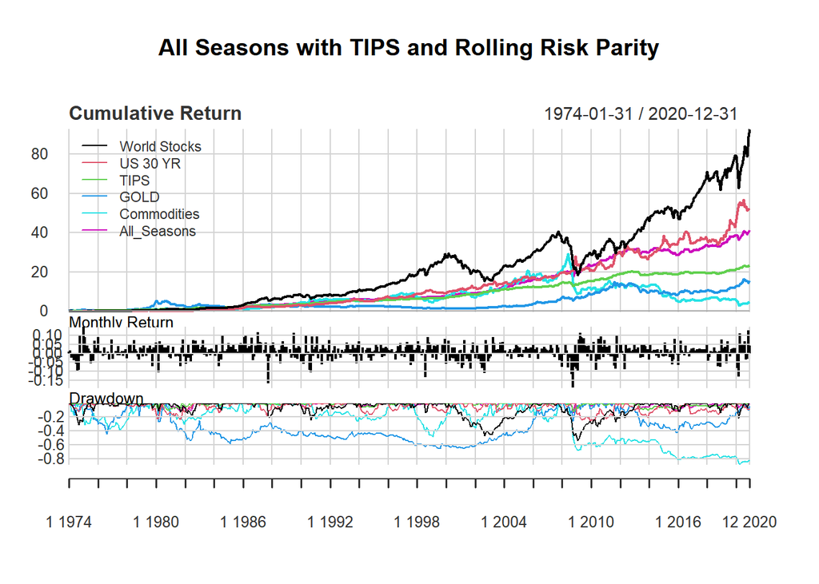

```r
port_All_Seasons_5 = Return.portfolio(R = rets_All_Seasons_5, weights = parity.weights)
All_Seasons_5 = cbind(rets_All_Seasons_5, port_All_Seasons_5) %>% setNames(c('World Stocks', 'US 30 YR', 'TIPS', 'GOLD',
                                                                             'Commodities', 'All_Seasons'))

charts.PerformanceSummary(All_Seasons_5, main = 'All Seasons with TIPS and Rolling Risk Parity')
```

```r
Return.cumulative(port_All_Seasons_5)
Return.annualized(port_All_Seasons_5)
Return.cumulative(rets_All_Seasons_5)
Return.annualized(rets_All_Seasons_5)

StdDev.annualized(port_All_Seasons_5)
StdDev.annualized(rets_All_Seasons_5)

SharpeRatio.annualized(port_All_Seasons_5, Rf = ReturnTimeSeries$`T-Bills`[889:1452], geometric = TRUE)
SharpeRatio.annualized(rets_All_Seasons_5, Rf = ReturnTimeSeries$`T-Bills`[889:1452], geometric = TRUE)

maxDrawdown(port_All_Seasons_5)
maxDrawdown(rets_All_Seasons_5)
```

표 19: All Seasons_5 (with TIPS and Rolling Risk Parity) 성과: 1974.01 ~ 2020.12

| 전략 | 누적 수익 | 연복리 수익률 | 표준편차 | 샤프 비율 | 최대 하락폭 |
| --- | --- | --- | --- | --- | --- |
| All Seasons | 42.2배 | 8.29% | 6.80% | 0.524 | 13.28% |
| World Stock | 93.9배 | 10.15% | 14.99% | 0.356 | 53.65% |
| US 30 YR | 52.5배 | 8.79% | 12.81% | 0.316 | 25.84% |
| TIPS | 24.4배 | 7.04% | 6.08% | 0.389 | 11.89% |
| GOLD | 16.6배 | 6.15% | 19.22% | 0.078 | 64.97% |
| Commodities | 5.7배 | 3.77% | 20.48% | -0.037 | 80.90% |

```
##         From     Trough         To   Depth Length To Trough Recovery
## 1 2008-07-31 2008-10-31 2008-12-31 -0.1328      6         4        2
## 2 2014-07-31 2015-12-31 2017-10-31 -0.1187     40        18       22
## 3 1980-10-31 1981-09-30 1982-09-30 -0.1103     24        12       12
## 4 1980-02-29 1980-03-31 1980-05-31 -0.1023      4         2        2
## 5 2013-05-31 2013-06-30 2014-06-30 -0.0803     14         2       12
```

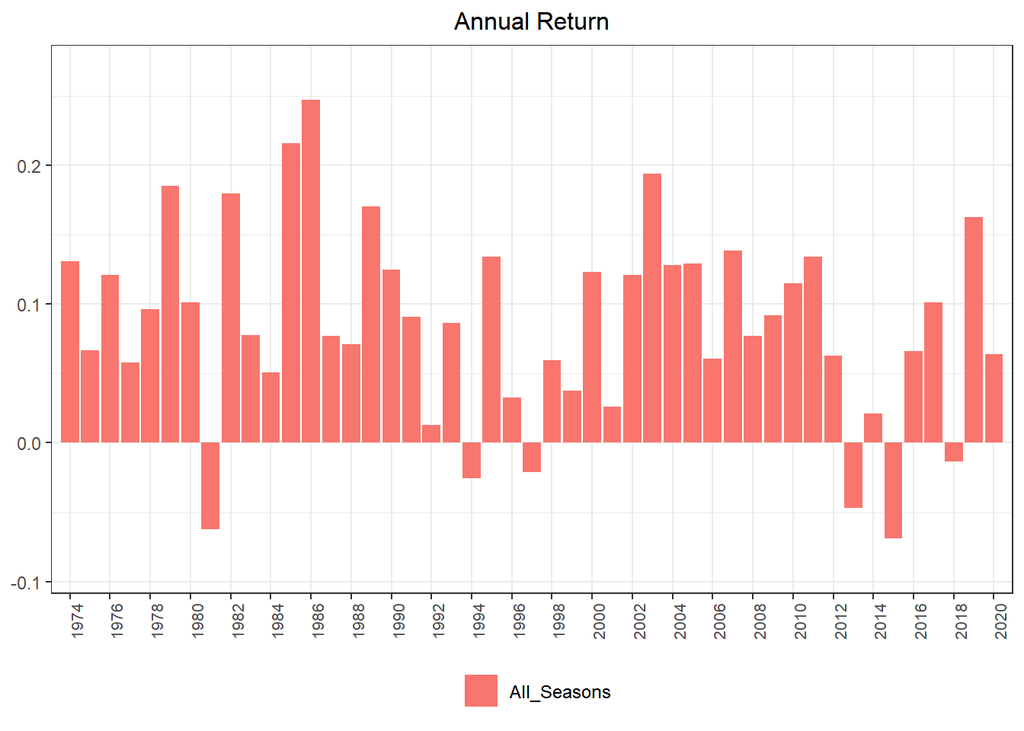

```r
table.Drawdowns(port_All_Seasons_5)
```

1974년 1월부터 누적 수익 42.2배, 연복리 수익률 8.29%, 연간 변동성 6.80%, 샤프 비율 0.524, 최대 하락폭 13.28%를 기록합니다. 다른 All Seasons 전략보다 변동성이 낮고 최대 하락폭이 작은 강점이 있습니다.

지금의 테스트는 레버리지 없이 구현한 결과입니다. Risk Parity 전략은 구조적으로 변동성이 낮은 자산에 비중이 크게 실리게 됩니다. 그러므로, 변동성이 낮은 자산에 레버리지를 사용하여 변동성을 키우고, 다른 기대 수익률이 더 높은 자산 비중을 늘려 수익을 더 추구할 수 있습니다. RPAR라는 ETF가 이런 방식으로 구현되어 있습니다. 주식, 국채, TIPS, 금, 원자재 생산 기업 주식을 편입한 ETF로 국채에 레버리지를 하고 나머지 자산군 비중을 높이는 방식입니다. 그들은 장기적으로 주식 25%, 원자재 생산 기업 주식 15%, 금 17.5%, 국채 42.5%, TIPS 20%로 120% 비중을 맞춥니다. 국채에 선물을 사용해서 레버리지를 구현하기 때문에 현금이 담보로 필요하고, 그것이 음의 비중을 가져가서 100%가 맞춰집니다. 변동성이 낮은 자산에 레버리지를 하는 것은 타당하나, 레버리지 비율을 어떤 기준으로 잡은 것인지, 어떤 자산군의 비중을 언제/얼마나 바꾸는지에 대한 설명이 모호합니다.

또 다른 방식은 포트폴리오 전체의 risk parity를 맞추면서 target volatility를 설정해서 시장의 변동성이 작을 때는 레버리지를 가하고, 변동성이 클 때는 시장 노출을 1 미만으로 하여 동적으로 투자 비중을 조정하는 방식입니다. Bridgewater Associates의 베타 펀드인 All Weather 펀드, 동적 자산배분의 유행을 이끈 Resolve Asset Management의 펀드 등 헤지펀드에서 좋아하는 방식입니다. 이 방식으로 다시 구현해 보겠습니다.

이전까지는 risk parity 계산에 패키지들을 주로 사용했습니다. 편하지만 입맛에 맞게 변형하기에는 제한적이므로, risk parity도 직접 구현하도록 하겠습니다.

```r
RiskParity_Objective = function(x){

  variance = t(x) %*% covmat %*% x
  sigma = sqrt(variance)
  MRC = (covmat %*% x) / as.numeric(sigma)

  rc = x * MRC
  rc_target = matrix(1/ncol(covmat) * sigma, nrow(covmat), 1)
  sum_risk_diff = sum((rc - rc_target)^2)

  return(sum_risk_diff)

}
```

구해진 rc 값과 rc_target의 차이를 최대한 줄이는 방향으로 최적화할 것입니다. 이제 제약 조건을 걸어야 합니다.

```r
inequal_objective = function(x){
  return(x)
}

equal_objective = function(x){
  return(sum(x)-1)
}
```

Inequality 제약조건은 종목들 비중이 0보다 큰 조건이면 됩니다. Equality 제약조건은 종목 비중 합이 1이 되면 됩니다.

```r
RiskParity = function(r){

  covmat = cov(r)

  RiskParity_Objective = function(x){

  variance = t(x) %*% covmat %*% x
  sigma = sqrt(variance)
  MRC = (covmat %*% x) / as.numeric(sigma)

  rc = x * MRC
  rc_target = matrix(1/ncol(covmat) * sigma, nrow(covmat), 1)
  sum_risk_diff = sum((rc - rc_target)^2)

  return(sum_risk_diff)

  }

  inequal_objective = function(x){
    return(x)
  }

  equal_objective = function(x){
    return(sum(x)-1)
  }

  x0.equal = rep(1/ncol(covmat), ncol(covmat))

  result = slsqp(x0 = x0.equal, fn = RiskParity_Objective, hin = inequal_objective, heq = equal_objective,
                 control = list(xtol_rel = 1e-20, maxeval = 5000))

  return(result)

}
```

잘 도는지 보겠습니다.

```r
RiskParity(rets_All_Seasons_3)
```

```
## $par
## [1] 0.1767136 0.2198647 0.3382534 0.1303736 0.1347947
##
## $value
## [1] 6.095567e-24
##
## $iter
## [1] 5000
##
## $convergence
## [1] 5
##
## $message
## [1] "NLOPT_MAXEVAL_REACHED: Optimization stopped because maxeval (above) was reached."
```

이전에 cccp 패키지의 rp() 함수로 구한 것과 거의 같은 값이 나옵니다. 잘 작동하는 것으로 볼 수 있습니다. 이제 target volatility를 적용할 수 있도록 제약 조건을 바꾸겠습니다.

```r
RiskParity_TargetVol = function(r, target){

  covmat = cov(r)

  RiskParity_Objective = function(x){

  variance = t(x) %*% covmat %*% x
  sigma = sqrt(variance)
  MRC = (covmat %*% x) / as.numeric(sigma)

  rc = x * MRC
  rc_target = matrix(1/ncol(covmat) * sigma, nrow(covmat), 1)
  sum_risk_diff = sum((rc - rc_target)^2)

  return(sum_risk_diff)

  }

  TargetVol = function(x){

    variance = t(x) %*% covmat %*% x
    sigma = sqrt(variance)
    sigma_annualized = sigma * sqrt(12)

    constr = vector("numeric", length = 2)

    constr[1] = sigma_annualized - target * 0.95
    constr[2] = target * 1.05 - sigma_annualized

    return(constr)

  }

  x0.equal = rep(1/ncol(covmat), ncol(covmat))

  result = nloptr(x0 = x0.equal, eval_f = RiskParity_Objective, eval_g_ineq = TargetVol,
                  opts = list("algorithm" = "NLOPT_LN_COBYLA", "xtol_rel" = 1e-20, "maxeval" = 5000))

  return(result)

}
```

Target Volatility를 잡는데, 그 값에서 상하 5% 이하로 움직이도록 했습니다. 예를 들어 target이 10%면 9.5% ~ 10.5% 사이에 위치하게 과거 변동성 기반으로 최적화합니다. 이제 rolling 기준으로 작동하는지 보겠습니다. 매달 이전 12개월 동안의 변동성을 가지고 risk parity와 target volatility를 맞추어 비중을 구하는 것으로 하겠습니다. 비중 합이 1이 아닐 수 있으므로, 1 - 비중 총합을 같이 기록해 두고 현금 비중으로 사용할 것입니다.

```r
weight_vec = vector('numeric', 6)

i = 1

while(i < nrow(rets_All_Seasons_3)-10){

  temp_vec = RiskParity_TargetVol(rets_All_Seasons_3[i:(i+11)], 0.1)$solution
  temp_vec = c(temp_vec, 1-sum(temp_vec))

  weight_vec = rbind(weight_vec, temp_vec)

  i = i + 1

}

# 다 넣은 후 맨 위에 생긴 zero row 제거
weight_vec = weight_vec[2:565, 1:6]

# xts 시계열로 변환
weight_vec = xts(weight_vec, order.by = ReturnData$`Data Index`[889:1452])
```

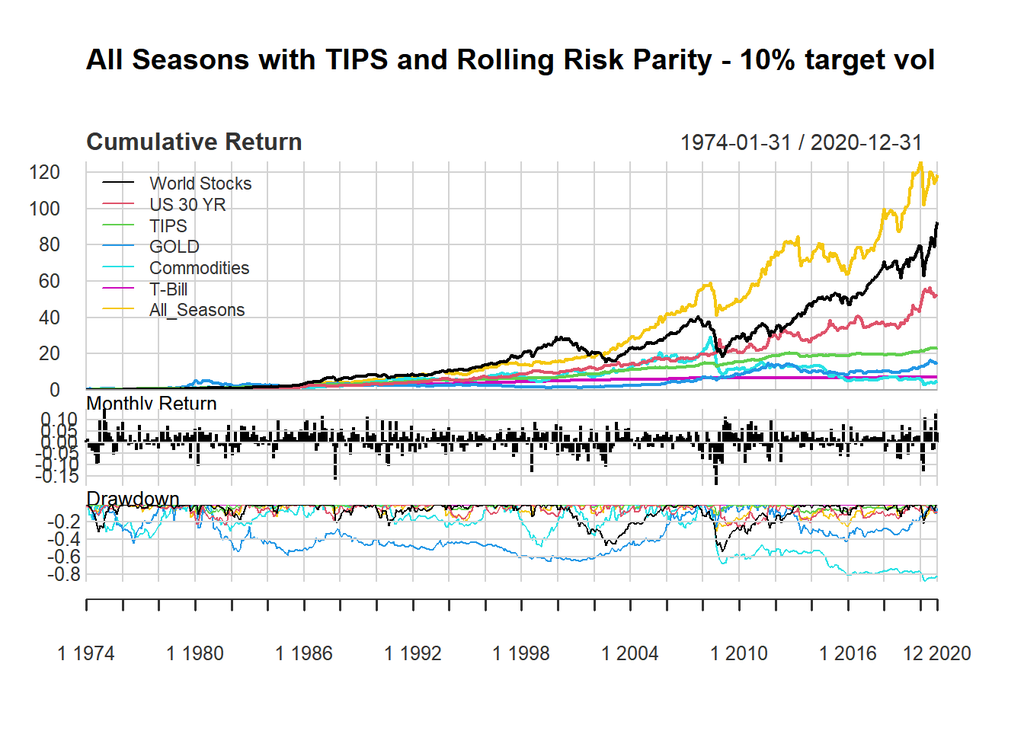

```r
port_All_Seasons_6 = Return.portfolio(R = rets_All_Seasons_6, weights = weight_vec)
All_Seasons_6 = cbind(rets_All_Seasons_6, port_All_Seasons_6) %>% setNames(c('World Stocks', 'US 30 YR', 'TIPS', 'GOLD',
                                                                             'Commodities', 'T-Bill', 'All_Seasons'))

charts.PerformanceSummary(All_Seasons_6, main = 'All Seasons with TIPS and Rolling Risk Parity - 10% target vol')
```

```r
Return.cumulative(port_All_Seasons_6)
Return.annualized(port_All_Seasons_6)
Return.cumulative(rets_All_Seasons_6)
Return.annualized(rets_All_Seasons_6)

StdDev.annualized(port_All_Seasons_6)
StdDev.annualized(rets_All_Seasons_6)

SharpeRatio.annualized(port_All_Seasons_6, Rf = ReturnTimeSeries$`T-Bills`[889:1452], geometric = TRUE)
SharpeRatio.annualized(rets_All_Seasons_6, Rf = ReturnTimeSeries$`T-Bills`[889:1452], geometric = TRUE)

maxDrawdown(port_All_Seasons_6)
maxDrawdown(rets_All_Seasons_6)
```

표 20: All Seasons_6 (with TIPS and Rolling Risk Parity - 10% target vol) 성과: 1974.01 ~ 2020.12

| 전략 | 누적 수익 | 연복리 수익률 | 표준편차 | 샤프 비율 | 최대 하락폭 |
| --- | --- | --- | --- | --- | --- |
| All Seasons | 118.7배 | 10.72% | 12.96% | 0.454 | 30.11% |
| World Stock | 93.9배 | 10.15% | 14.99% | 0.356 | 53.65% |
| US 30 YR | 52.5배 | 8.79% | 12.81% | 0.316 | 25.84% |
| TIPS | 24.4배 | 7.04% | 6.08% | 0.389 | 11.89% |
| GOLD | 16.6배 | 6.15% | 19.22% | 0.078 | 64.97% |
| Commodities | 5.7배 | 3.77% | 20.48% | -0.037 | 80.90% |

```
##         From     Trough         To   Depth Length To Trough Recovery
## 1 2008-07-31 2008-10-31 2011-02-28 -0.3011     32         4       28
## 2 2013-05-31 2015-12-31 2017-10-31 -0.2439     54        32       22
## 3 1993-09-30 1994-11-30 1995-05-31 -0.1916     21        15        6
## 4 2020-02-28 2020-03-31       <NA> -0.1890     12         2       NA
## 5 1979-10-31 1979-10-31 1980-06-30 -0.1472      9         1        8
```

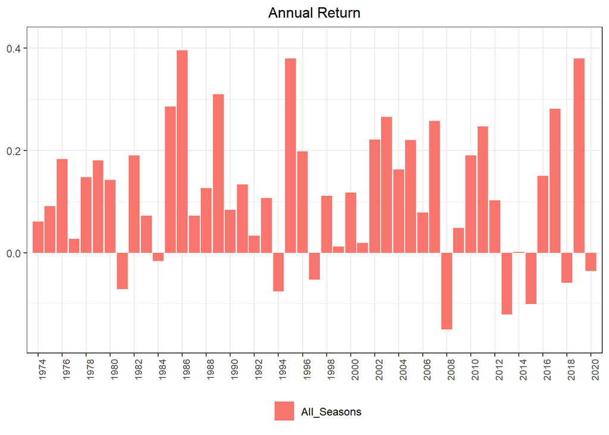

```r
table.Drawdowns(port_All_Seasons_6)
```

Bridgewater Associates에서 risk parity fund의 target volatility 중 하나로 제시했던 10% target volatilty의 성과입니다. Target volatility와 Risk Parity를 동시에 맞추므로 레버리지를 사용하는 구간이 많습니다. 1974년 1월부터 누적 수익률 118.7배, 연 복리 수익률 10.71%, 연 변동성 12.96%, 샤프 비율 0.454, 최대 하락폭 30.11%입니다. 목표 변동성을 10%로 잡았으나 실제로는 12.96%가 나와 변동성이 예상보다 컸습니다. 그러나, 주식 시장을 이기면서 변동성은 더 낮은 괜찮은 전략입니다.

# 4. 마켓 타이밍

지금까지 본 전략들은 자산 배분 비중을 정한 채로 사서 버티거나, 과거 변동성에 따라 비율을 조정하는 전략이었습니다. 그 외에, 자산의 가격, 수익률, 기타 다른 지표로 시장 타이밍을 잡고 움직이는 방법도 있습니다. 이제 이런 방법을 보겠습니다.

## 4.1 상대/절대/듀얼 모멘텀

상대 모멘텀 전략은 여러 자산들 중 모멘텀이(추세가) 상대적으로 좋은 자산을 매수하고, 이후 리밸런싱에서 다시 모멘텀이 좋은 자산으로 바꾸어주는 전략입니다. 절대 모멘텀 전략은 자산 각각의 과거와 비교합니다. 예를 들어, 주식 시장 수익률이 현금 수익률보다 좋으면 주식 시장 ETF를 보유하고, 현금 수익률보다 나쁘면 현금을 보유합니다. 듀얼 모멘텀은 상대와 절대 모멘텀을 합친 방식으로, 여러 자산의 모멘텀을 비교하여 모멘텀이 높은 것들을 선택하고(상대), 선택된 각 자산의 수익률이 현금 수익률보다 못하면 현금을 보유하도록 하는(절대) 전략입니다. 모멘텀과 관련하여 두 가지 전략을 보겠습니다.

첫 번째 전략은 섹터 로테이션 전략입니다. 섹터 ETF들로 테스트합니다. 섹터별 목록은 다음과 같습니다.

표 21: 섹터 ETF

| TICKER | SECTOR |
| --- | --- |
| XLC | Communication Services |
| XLY | Consumer Discretionary |
| XLP | Consumer Staples |
| XLE | Energy |
| XLF | Financials |
| XLV | Healthcare |
| XLI | Industrials |
| XLB | Materials |
| XLRE | Real Estate |
| XLK | Technology |
| XLU | Utilities |

총 11개가 있는데, 이 중 나온지 얼마 되지 않은 XLC (2018-06-18), XLRE (2015-10-07) 두 가지를 제외하고 9개에 대해서 테스트합니다. 9개 섹터 중 최근 12개월 누적 수익률 상위 5개 섹터를 선택 후 12개월 누적 수익률이 양수인 섹터만 선택합니다. 선택된 섹터에 20%씩 비중을 부여하고, 남는 비중은 단기 국채로 가져갑니다.

```r
symbols = c("XLY", "XLP", "XLE", "XLF", "XLV", "XLI", "XLB", "XLK", "XLU", "SHY")
symbols_bm = c("SPY")

# 가격 데이터 다운로드
getSymbols(c(symbols, symbols_bm), src = 'yahoo', from = '1998-12-31', to = '2021-01-29')
```

```
##  [1] "XLY" "XLP" "XLE" "XLF" "XLV" "XLI" "XLB" "XLK" "XLU" "SHY" "SPY"
```

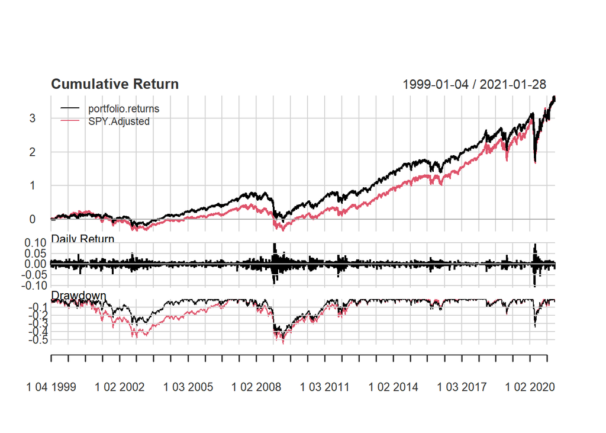

```r
prices = list()
for(i in 1:length(symbols)){
  prices[[i]] = Ad(get(symbols[[i]]))
}
prices = do.call(cbind, prices)

bm = Ad(get(symbols_bm))

rets = na.omit(Return.calculate(prices[, -ncol(prices)]))
ret_cash = na.omit(Return.calculate(prices[, ncol(prices)]))
ret_bm = na.omit(Return.calculate(bm))

num = 5
lookback = 12

wts = list()
ep = endpoints(rets, on = "months")

for(i in (lookback+1):length(ep)){

  # 12개월 누적 수익률
  sub_cum = Return.cumulative(rets[c(ep[i-12] : ep[i]), ])

  # 가져가는 자산 개수: 상위 5위까지 & 누적 수익률 0 이상
  K = which(rank(- sub_cum) <= num & sub_cum >= 0)

  # 매달 비중 결정
  wt = rep(0, ncol(rets))
  wt[K] = 1/num
  names(wt) = colnames(rets)
  wt = xts(t(wt), order.by = index(rets[ep[i]]))
  wts[[i]] = wt
}

# 비중 모음
wts = round(do.call(rbind, wts), 3)
wts$zeros = 1 - rowSums(wts)
rets$zeros = ret_cash

Sector_Rot = Return.portfolio(R = rets, weigths = wts, verbose = TRUE)
Sector_Rot_ret = Sector_Rot$return

comparison = na.omit(cbind(Sector_Rot_ret, ret_bm))
charts.PerformanceSummary(comparison, main = "")
```

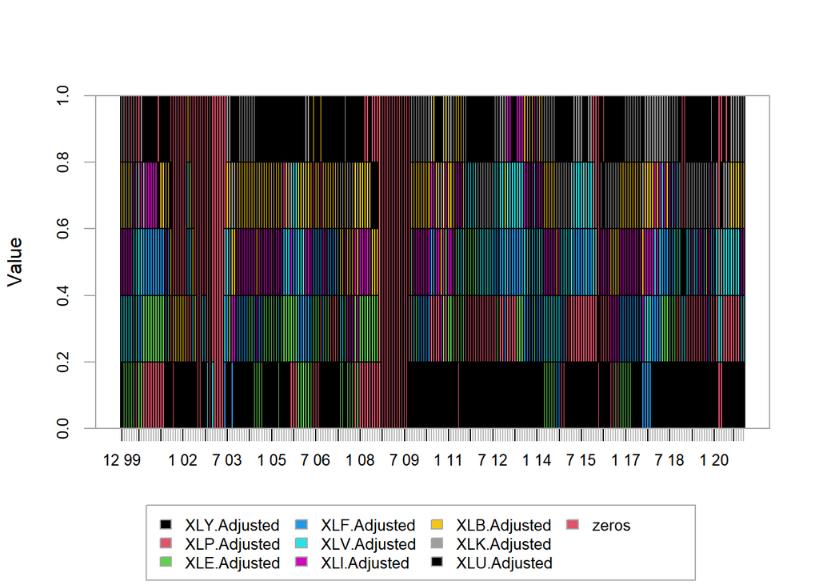

```r
chart.StackedBar(wts)
```

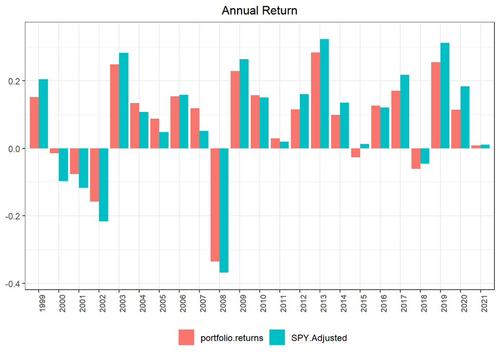

표 22: 섹터 로테이션 전략 성과

| 전략 | 누적 수익 | 연복리 수익률 | 표준편차 | 샤프 비율 | 최대 하락폭 |
| --- | --- | --- | --- | --- | --- |
| Sector Rotation | 4.55배 | 7.11% | 17.45% | 0.392 | 48.68% |
| Benchmark(SPY) | 4.59배 | 7.16% | 19.80% | 0.393 | 55.19% |

```r
Return.cumulative(Sector_Rot_ret)
Return.cumulative(ret_bm)
Return.annualized(Sector_Rot_ret)
Return.annualized(ret_bm)
StdDev.annualized(Sector_Rot_ret)
StdDev.annualized(ret_bm)
SharpeRatio.annualized(Sector_Rot_ret, ret_cash, geometric = TRUE)
SharpeRatio.annualized(ret_bm, ret_cash, geometric = TRUE)
maxDrawdown(Sector_Rot_ret)
maxDrawdown(ret_bm)
```

상대 모멘텀과 절대 모멘텀을 활용한 섹터 로테이션 전략의 테스트 결과입니다. 수익률은 시장과 비슷하고 변동성은 약간 낮습니다. 금융위기 때 현금 100%로 대피하는 것을 볼 수 있습니다. 이제 주식 섹터 말고 다른 자산군들을 가지고 비슷한 전략을 구현해 보겠습니다.

표 23: 글로벌 자산군

| TICKER | Category |
| --- | --- |
| VIVAX | Large Cap Value |
| VIGRX | Large Cap Growth |
| VISVX | Small Cap Value |
| VISGX | Small cap Growth |
| VTMGX | Developed Market Stock |
| VEIEX | Emerging Market Stock |
| PGBIX | Global Bond |
| VFITX | US Intermediate Term Treasury |
| LQD | Corporate Bond |
| TLT | Long Term Treasury |
| IAU | Gold |
| GSG | Commodities |
| VGSIX | Real Estate |

[output not shown]

```
##  [1] "VIVAX" "VIGRX" "VISVX" "VISGX" "VTMGX" "VEIEX" "VFITX" "PGBIX" "LQD"
## [10] "TLT"   "IAU"   "GSG"   "VGSIX" "SHY"   "SPY"
```

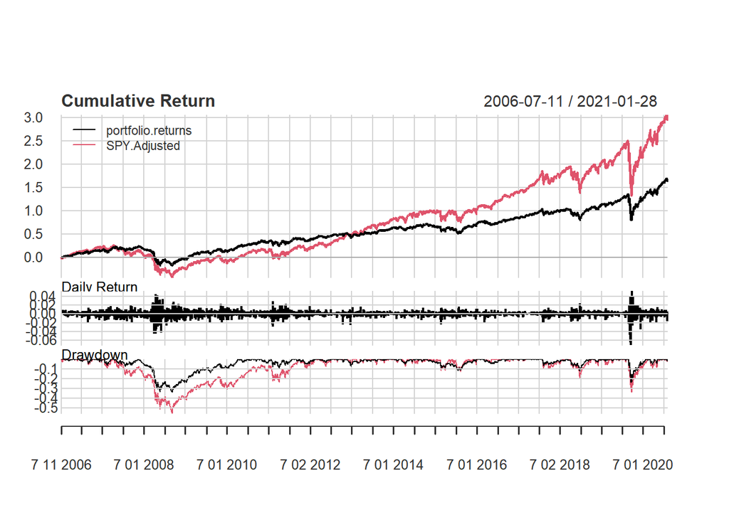

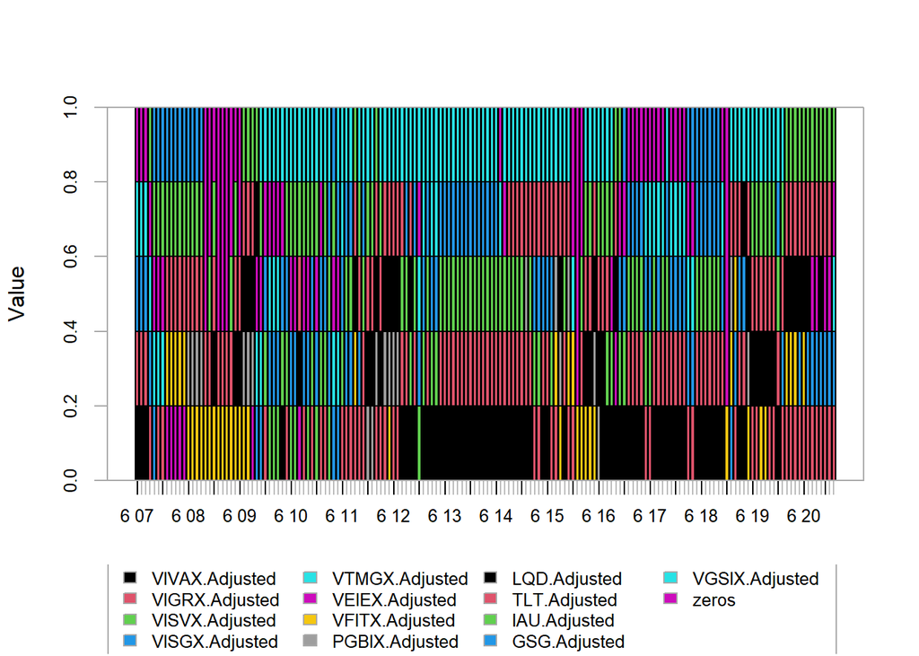

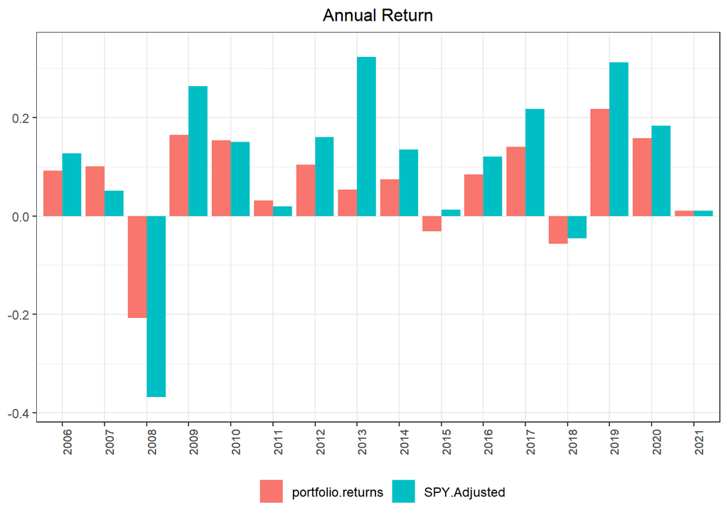

표 24: 자산군 로테이션 전략 성과

| 전략 | 누적 수익 | 연복리 수익률 | 표준편차 | 샤프 비율 | 최대 하락폭 |
| --- | --- | --- | --- | --- | --- |
| Asset Rotation | 2.65배 | 6.94% | 11.03% | 0.423 | 33.74% |
| Benchmark(SPY) | 3.99배 | 9.99% | 20.31% | 0.373 | 55.19% |

```r
Return.cumulative(Asset_Rot_ret)
Return.cumulative(ret_bm)
Return.annualized(Asset_Rot_ret)
Return.annualized(ret_bm)
StdDev.annualized(Asset_Rot_ret)
StdDev.annualized(ret_bm)
SharpeRatio.annualized(Asset_Rot_ret, ret_cash, geometric = TRUE)
SharpeRatio.annualized(ret_bm, ret_cash, geometric = TRUE)
maxDrawdown(Asset_Rot_ret)
maxDrawdown(ret_bm)
```

자산군 로테이션 전략입니다. 수익률 자체는 비교 대상인 주식 시장보다 못하나, 샤프 비율이 시장보다 높습니다. 그러나, 섹터 로테이션 전략과 자산군 로테이션 전략 모두 잦은 거래에 따른 거래 비용을 고려하게 되면 수익률이 더 악화될 것입니다. 모멘텀 전략이 잘 먹히는 구간에서는 괜찮은 전략이지만, 모멘텀 전략이 작동하지 않으면 거래 비용만 내고 별다른 이득은 얻을 수 없습니다.